# Point estimation: live R demonstrations

POLI 210 - Seminar 7

Author

Brad LeVeck

Published

October 14, 2026

Open this QMD in RStudio. **Each numbered code chunk runs independently in a fresh R session.** No downloaded data, packages beyond base R, or helper files are needed. Start with the experiment and the target, predict the result, then run the code. All data here are simulated or hypothetical.

**Main seminar:** Demos 1-4 prepare for B3. **Optional extension:** Demos 5-7 cover estimated variance and studentization; save them for later if needed.

## 1. One estimate per study

For a simple model inspired by the turnout example, imagine two independent samples of 200 voters, with turnout probabilities 0.378 and 0.315. This is not a reconstruction of the original experiment’s assignment design or SEs. The true difference is 0.063, or 6.3 percentage points.

**Predict:** Will every estimate equal the truth? What should its average be?

```r
set.seed(210071)
B <- 10000
n_per_group <- 200
p1 <- .378
p0 <- .315
truth <- p1 - p0
estimates <- replicate(B, {
  y1 <- rbinom(n_per_group, size = 1, prob = p1)
  y0 <- rbinom(n_per_group, size = 1, prob = p0)
  mean(y1) - mean(y0)
})
c(truth = truth,
  average_estimate = mean(estimates),
  bias = mean(estimates) - truth,
  sampling_sd = sd(estimates),
  theoretical_se = sqrt(p1 * (1 - p1) / n_per_group +
                         p0 * (1 - p0) / n_per_group),
  mse = mean((estimates - truth)^2),
  within_one_pp = mean(abs(estimates - truth) <= .01))
```

```
           truth average_estimate             bias      sampling_sd
      0.06300000       0.06301000       0.00001000       0.04688976
  theoretical_se              mse    within_one_pp
      0.04748110       0.00219843       0.16750000
```

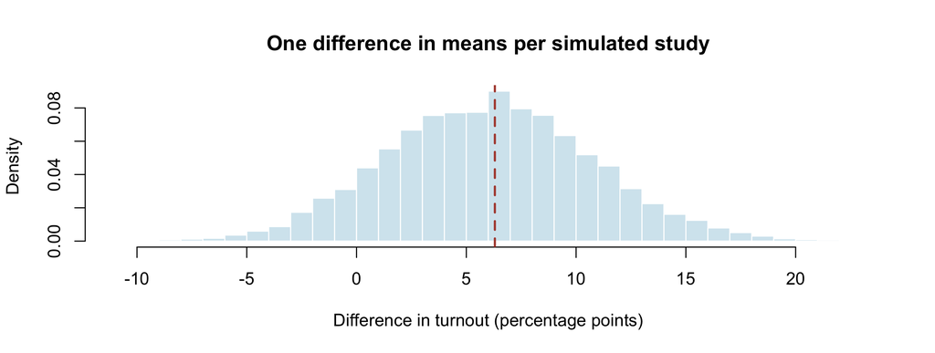

```r
hist(100 * estimates, breaks = 30, freq = FALSE,
     col = "#D4E7EF", border = "white",
     xlab = "Difference in turnout (percentage points)",
     main = "One difference in means per simulated study")
abline(v = 100 * truth, col = "#B04C3E", lwd = 2, lty = 2)
```

**Pause:** Change `n_per_group` to 800, leaving B fixed. Then restore n and change B. Which change affects the estimator’s actual sampling distribution? The one-point tolerance is `.01` because this code uses proportions.

## 2. Unbiasedness versus consistency

Here observations are IID Normal with mean 5 and SD 2. Compare the sample mean, the first observation, and the sample mean plus 2. The last estimator is deliberately flawed; it makes the distinction visible.

```r
set.seed(210074)
B <- 10000
mu <- 5
sigma <- 2
sizes <- c(4, 16, 64)
results <- lapply(sizes, function(n) {
  estimates <- replicate(B, {
    x <- rnorm(n, mean = mu, sd = sigma)
    c(Mean = mean(x), First = x[1], Shifted_mean = mean(x) + 2)
  })
  data.frame(n = n, estimator = rownames(estimates),
             average = rowMeans(estimates),
             sampling_sd = apply(estimates, 1, sd),
             bias = rowMeans(estimates) - mu,
             mse = rowMeans((estimates - mu)^2),
             within_one = rowMeans(abs(estimates - mu) <= 1),
             row.names = NULL)
})
do.call(rbind, results)
```

```
   n    estimator  average sampling_sd          bias        mse within_one
1  4         Mean 4.994755   0.9995638 -0.0052448593 0.99905537     0.6849
2  4        First 4.999883   1.9697931 -0.0001173979 3.87969696     0.3870
3  4 Shifted_mean 6.994755   0.9995638  1.9947551407 4.97807594     0.1595
4 16         Mean 4.989807   0.4940275 -0.0101927316 0.24414267     0.9562
5 16        First 4.946677   2.0103867 -0.0533227380 4.04409370     0.3795
6 16 Shifted_mean 6.989807   0.4940275  1.9898072684 4.20337174     0.0230
7 64         Mean 4.999791   0.2516695 -0.0002089563 0.06333122     0.9999
8 64        First 4.973436   1.9976756 -0.0265642601 3.99101446     0.3834
9 64 Shifted_mean 6.999791   0.2516695  1.9997910437 4.06249540     0.0001
```

Which estimator remains centered at 5 but does not concentrate? Which becomes precise about the wrong value? Simulation illustrates this; the expectation and variance formulas establish the claims.

## 3. Potential outcomes and every possible assignment

This **four-unit** example is different from B3. Outcomes are hypothetical percentages. We know both potential outcomes only because we invented the population. Fix these four units and randomly assign exactly two to treatment.

```r
y0 <- c(10, 20, 15, 25)
y1 <- c(15, 22, 21, 25)
truth <- mean(y1 - y0)
diff_means <- function(y, D) mean(y[D == 1]) - mean(y[D == 0])
D <- as.integer((1:4) %in% c(1, 3))
y <- ifelse(D == 1, y1, y0)
data.frame(unit = 1:4, y0, y1, effect = y1 - y0, D, observed = y)
```

```
  unit y0 y1 effect D observed
1    1 10 15      5 1       15
2    2 20 22      2 0       20
3    3 15 21      6 1       21
4    4 25 25      0 0       25
```

```r
c(ATE = truth, this_estimate = diff_means(y, D))
```

```
          ATE this_estimate
         3.25         -4.50
```

```r
# Each COLUMN is one possible treated pair. All six are equally likely.
assignments <- combn(1:4, 2)
assignments
```

```
     [,1] [,2] [,3] [,4] [,5] [,6]
[1,]    1    1    1    2    2    3
[2,]    2    3    4    3    4    4
```

```r
estimates <- apply(assignments, 2, function(treated) {
  D <- as.integer((1:4) %in% treated)
  y <- ifelse(D == 1, y1, y0)
  diff_means(y, D)
})
data.frame(treated = apply(assignments, 2, paste, collapse = ", "), estimates)
```

```
  treated estimates
1    1, 2      -1.5
2    1, 3      -4.5
3    1, 4       2.5
4    2, 3       4.0
5    2, 4      11.0
6    3, 4       8.0
```

```r
c(exact_expectation = mean(estimates), truth = truth,
  exact_bias = mean(estimates) - truth)
```

```
exact_expectation             truth        exact_bias
             3.25              3.25              0.00
```

```r
# Now the original pair ALWAYS selects treatment: no averaging over assignments.
selected_difference <- diff_means(y, D)
ATT <- mean((y1 - y0)[D == 1])
baseline_selection <- mean(y0[D == 1]) - mean(y0[D == 0])
c(observed_comparison = selected_difference,
  ATT = ATT, baseline_selection = baseline_selection,
  ATT_plus_selection = ATT + baseline_selection,
  ATE = truth, gap_from_ATE = selected_difference - truth)
```

```
observed_comparison                 ATT  baseline_selection  ATT_plus_selection
              -4.50                5.50              -10.00               -4.50
                ATE        gap_from_ATE
               3.25               -7.75
```

The temporary `D` and `y` inside the function belong to that calculation; the original four-unit assignment remains available outside it. The observed comparison is not the treated group’s average individual effect, nor is that treated effect necessarily the ATE. This is a useful place to do the add-and-subtract derivation on the board.

## 4. Reading concentration and simulation summaries

This final illustration directly simulates **estimators**, not raw outcomes. Both sampling SDs shrink, but one estimator targets the wrong value. These Normal distributions are invented to make CDF concentration easy to see; they are not assumptions about B3’s village estimator.

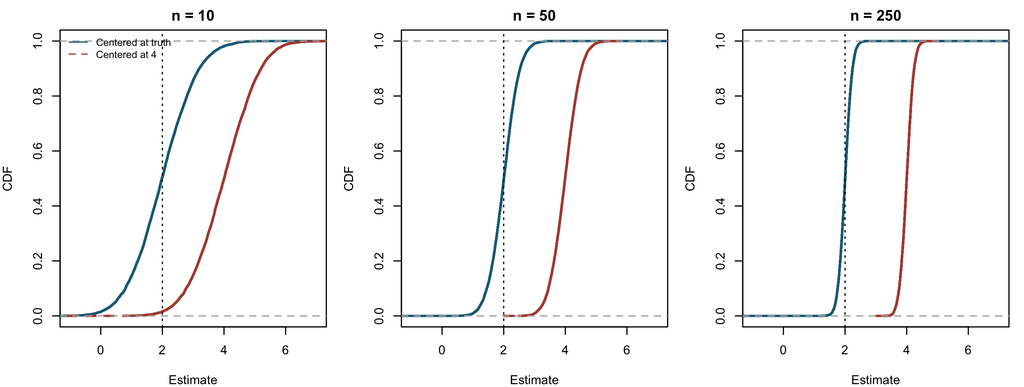

```r
set.seed(210076)
B <- 10000
truth <- 2
sizes <- c(10, 50, 250)
summary_rows <- list()
old <- par(mfrow = c(1, 3), mar = c(4, 4, 2, 1))
for (j in seq_along(sizes)) {
  n <- sizes[j]
  accurate <- rnorm(B, mean = truth, sd = 3 / sqrt(n))
  shifted <- rnorm(B, mean = truth + 2, sd = 3 / sqrt(n))
  plot(ecdf(accurate), do.points = FALSE, verticals = TRUE,
       col = "#176B87", lwd = 2, xlim = c(-1, 7),
       main = paste("n =", n), xlab = "Estimate", ylab = "CDF")
  lines(ecdf(shifted), do.points = FALSE, verticals = TRUE,
        col = "#B04C3E", lwd = 2, lty = 2)
  abline(v = truth, lty = 3)
  if (j == 1) legend("topleft", c("Centered at truth", "Centered at 4"),
                     col = c("#176B87", "#B04C3E"), lty = 1:2, bty = "n", cex = .8)
  for (design in c("accurate", "shifted")) {
    estimates <- if (design == "accurate") accurate else shifted
    summary_rows[[length(summary_rows) + 1]] <- data.frame(
      n = n, design = design, mean = mean(estimates),
      bias = mean(estimates) - truth,
      sampling_sd = sd(estimates),
      mse = mean((estimates - truth)^2),
      within_one = mean(abs(estimates - truth) <= 1),
      mcse_of_simulated_mean = sd(estimates) / sqrt(B))
  }
}
```

```r
par(old)
do.call(rbind, summary_rows)
```

```
    n   design     mean          bias sampling_sd        mse within_one
1  10 accurate 1.997320 -0.0026795123   0.9422835 0.88781659     0.7127
2  10  shifted 3.994492  1.9944923022   0.9391473 4.85990890     0.1476
3  50 accurate 2.000256  0.0002564666   0.4231194 0.17901223     0.9814
4  50  shifted 3.989819  1.9898189403   0.4206153 4.13627897     0.0094
5 250 accurate 2.003132  0.0031320778   0.1899490 0.03608683     1.0000
6 250  shifted 4.000761  2.0007606809   0.1913728 4.03966318     0.0000
  mcse_of_simulated_mean
1            0.009422835
2            0.009391473
3            0.004231194
4            0.004206153
5            0.001899490
6            0.001913728
```

The Monte Carlo SE describes precision in our **simulation of the estimator’s mean**. It is not the estimator’s sampling SD. Use `sd(estimates)` for the latter. `sd()` uses B − 1, so the numerical identity with simulation MSE is exact when variance is instead calculated as `mean((estimates - mean(estimates))^2)`; the difference is tiny at large B.

## 5. Optional: a biased but consistent variance estimator

We compare the squared deviations divided by n with R’s `var()`, which divides by n − 1. Both settle around the population variance, but only the latter is unbiased. The SD itself need not be unbiased.

```r
set.seed(210075)
B <- 10000
sigma <- 2
results <- lapply(c(5, 30, 100), function(n) {
  estimates <- replicate(B, {
    x <- rnorm(n, mean = 5, sd = sigma)
    c(divide_by_n = mean((x - mean(x))^2),
      divide_by_n_minus_1 = var(x))
  })
  data.frame(n = n, estimator = rownames(estimates),
             truth = sigma^2,
             expected = c((n - 1) / n * sigma^2, sigma^2),
             simulated_average = rowMeans(estimates),
             sampling_sd = apply(estimates, 1, sd), row.names = NULL)
})
do.call(rbind, results)
```

```
    n           estimator truth expected simulated_average sampling_sd
1   5         divide_by_n     4 3.200000          3.205569   2.2915671
2   5 divide_by_n_minus_1     4 4.000000          4.006961   2.8644589
3  30         divide_by_n     4 3.866667          3.855854   1.0097995
4  30 divide_by_n_minus_1     4 4.000000          3.988814   1.0446202
5 100         divide_by_n     4 3.960000          3.951343   0.5663554
6 100 divide_by_n_minus_1     4 4.000000          3.991256   0.5720761
```

## 6. Optional: Normal observations and an exact t distribution

Each simulated study calculates the mean and SD from the **same** sample. For IID Normal observations, the resulting statistic has an exact $t_{n-1}$ distribution. The empirical CDF only approximates that distribution.

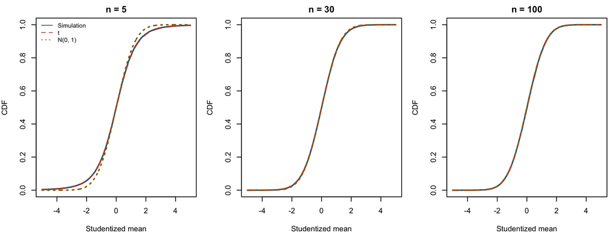

```r
set.seed(210072)
B <- 20000
mu <- 5
sigma <- 5
sizes <- c(5, 30, 100)
t_values <- lapply(sizes, function(n) replicate(B, {
  x <- rnorm(n, mean = mu, sd = sigma)
  (mean(x) - mu) / (sd(x) / sqrt(n))
}))
grid <- seq(-5, 5, length.out = 1000)
old <- par(mfrow = c(1, 3), mar = c(4, 4, 2, 1))
for (j in seq_along(sizes)) {
  n <- sizes[j]
  plot(grid, ecdf(t_values[[j]])(grid), type = "l", lwd = 2,
       col = "#176B87", ylim = c(0, 1), xlab = "Studentized mean",
       ylab = "CDF", main = paste("n =", n))
  lines(grid, pt(grid, df = n - 1), col = "#B04C3E", lwd = 2, lty = 2)
  lines(grid, pnorm(grid), col = "#957000", lwd = 2, lty = 3)
  if (j == 1) legend("topleft", c("Simulation", "t", "N(0, 1)"),
                     col = c("#176B87", "#B04C3E", "#957000"),
                     lty = 1:3, bty = "n", cex = .8)
}
```

```r
par(old)
data.frame(n = sizes,
           left_sim = sapply(t_values, function(z) mean(z < -2)),
           right_sim = sapply(t_values, function(z) mean(z > 2)),
           each_t_tail = pt(-2, df = sizes - 1),
           each_Normal_tail = pnorm(-2))
```

```
    n left_sim right_sim each_t_tail each_Normal_tail
1   5  0.05785   0.05610  0.05805826       0.02275013
2  30  0.02635   0.02740  0.02747182       0.02275013
3 100  0.02340   0.02385  0.02411985       0.02275013
```

`ecdf(t_values[[j]])` constructs a function. Applying it to `grid` evaluates the fraction of simulated statistics less than or equal to each grid point. The grid is for drawing curves; the full simulated vector is used for tail probabilities, including values beyond the displayed range.

## 7. Optional: Exponential observations and the t reference

Keep mean = 5 and SD = 5 but use a strongly right-skewed population. For an Exponential, both moments equal `1 / rate`. The simulation is otherwise the same. Look at the **two separate tails**, not just their sum.

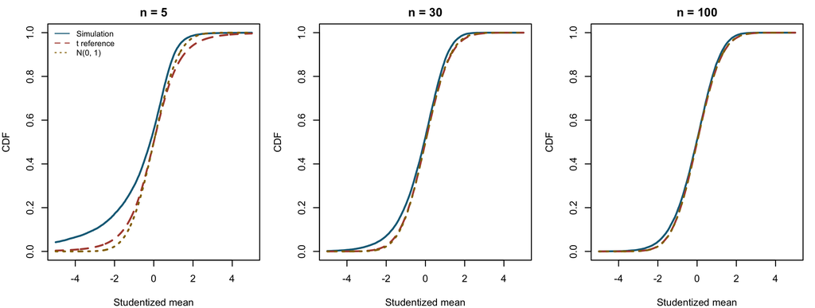

```r
set.seed(210073)
B <- 20000
mu <- 5
sizes <- c(5, 30, 100)
t_values <- lapply(sizes, function(n) replicate(B, {
  x <- rexp(n, rate = 1 / mu)
  (mean(x) - mu) / (sd(x) / sqrt(n))
}))
grid <- seq(-5, 5, length.out = 1000)
old <- par(mfrow = c(1, 3), mar = c(4, 4, 2, 1))
for (j in seq_along(sizes)) {
  n <- sizes[j]
  plot(grid, ecdf(t_values[[j]])(grid), type = "l", lwd = 2,
       col = "#176B87", ylim = c(0, 1), xlab = "Studentized mean",
       ylab = "CDF", main = paste("n =", n))
  lines(grid, pt(grid, df = n - 1), col = "#B04C3E", lwd = 2, lty = 2)
  lines(grid, pnorm(grid), col = "#957000", lwd = 2, lty = 3)
  if (j == 1) legend("topleft", c("Simulation", "t reference", "N(0, 1)"),
                     col = c("#176B87", "#B04C3E", "#957000"),
                     lty = 1:3, bty = "n", cex = .8)
}
```

```r
par(old)
data.frame(n = sizes,
           left_sim = sapply(t_values, function(z) mean(z < -2)),
           right_sim = sapply(t_values, function(z) mean(z > 2)),
           each_t_tail = pt(-2, df = sizes - 1),
           each_Normal_tail = pnorm(-2))
```

```
    n left_sim right_sim each_t_tail each_Normal_tail
1   5  0.17170   0.01355  0.05805826       0.02275013
2  30  0.07065   0.00820  0.02747182       0.02275013
3 100  0.04465   0.01265  0.02411985       0.02275013
```

**Discuss:** A small sample containing mostly small observations can produce both a low sample mean and a small sample SD. This can create a large negative ratio. The exact Normal-sampling independence result does not carry over. Finite positive variance still supports the CLT and the large-n studentized Normal limit. Do not interpret the t reference as an exact result here.

## References

Instructional structure and the turnout motivation adapt Matthew Blackwell’s [Estimation and Inference slides](https://www.mattblackwell.org/files/teaching/gov2000/s05-estimation-inference-slides-print.pdf), Sections 1-2, with permission. Potential-outcomes framing follows Gerber and Green (2012), *Field Experiments*, Chapter 2. Point estimation follows [PSD Section 5.6](https://probstatsdata.com/SimulationRV.html#pointestimators). All code and figures in this demonstration are original course illustrations.